# Datasaurus Dozen

Erick Knackstedt

2020-10-12

# TidyTuesday

## Load the weekly Data

```r
tt <- tt_load("2020-10-13")
datasaurus <- tt$datasaurus

theme_set(theme_bw())
```

## Analysis plan

We have multiple data sets that are designed to teach the principle that summaries are not the actual data. Here the data are distributed differently in all cases but undifferentiated when summarized with the mean, standard deviation, and correlation.

The mean is a description of a random variables’ center. The standard deviation a description of a random variables’ spread. Correlation is a measure of the covariation between two random variables.

Just looking at these statistics without taking the time to look at the data could lead an analyst to infer that data sets were observations from the same underlying machinery.

For this analysis we will explore the similar summaries visually. Then, we will view them using boxplots to see how much an alternate statistical approach can help. We will start with the quick vignette provide.

## The actual data

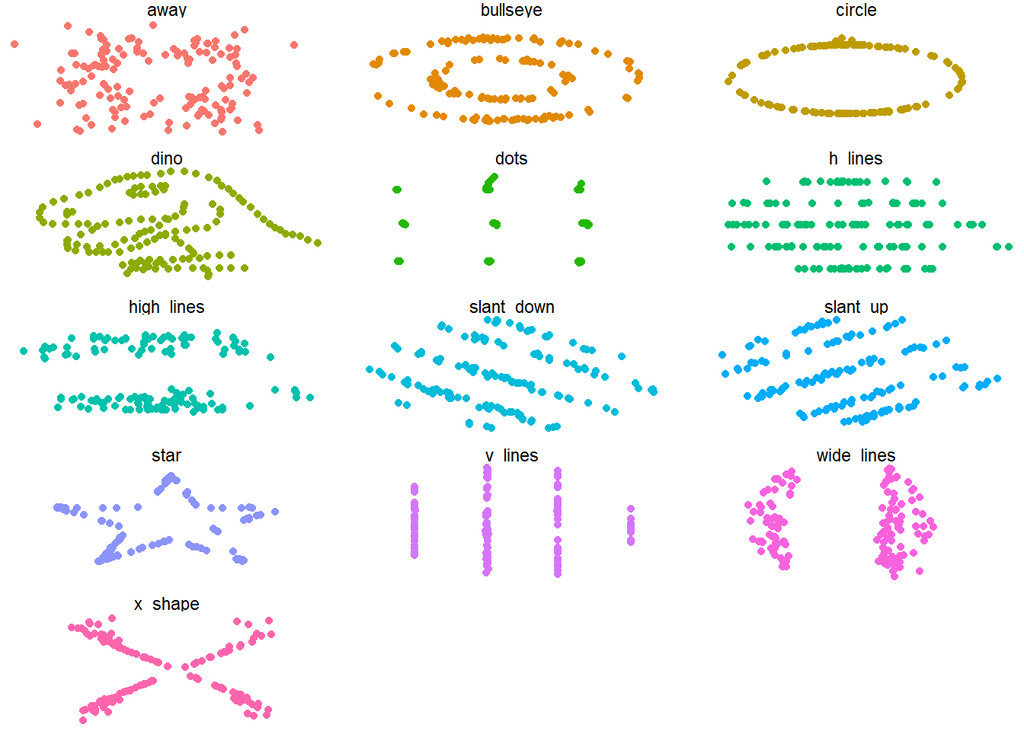

```r
ggplot(datasaurus, aes(x=x, y=y, colour=dataset))+
  geom_point()+
  theme_void()+
  theme(legend.position = "none")+
  facet_wrap(~dataset, ncol=3)
```

## Mean, standard deviation, and correlation

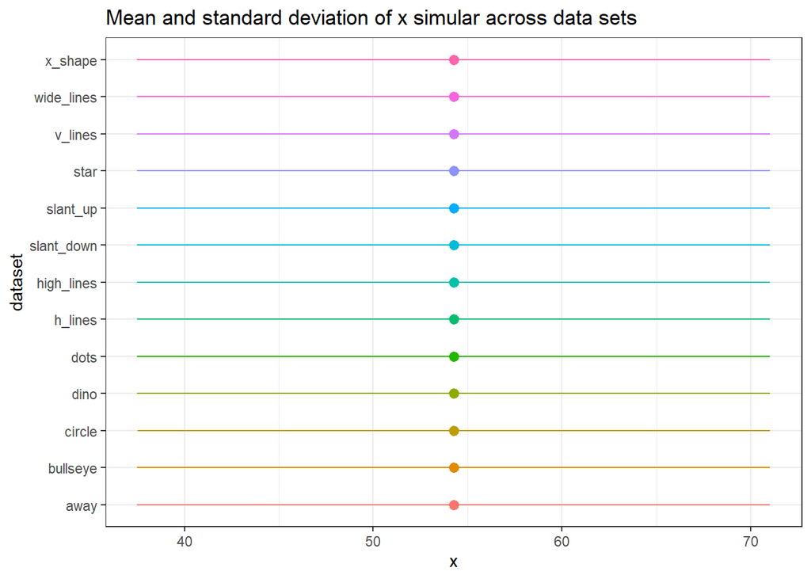

```r
ggplot(datasaurus, aes(x=x, y = dataset, colour=dataset))+
  stat_summary(fun.data = "mean_sdl",
               fun.args = list(mult = 1),
               show.legend = F) +
  labs(title = "Mean and standard deviation of x simular across data sets")
```

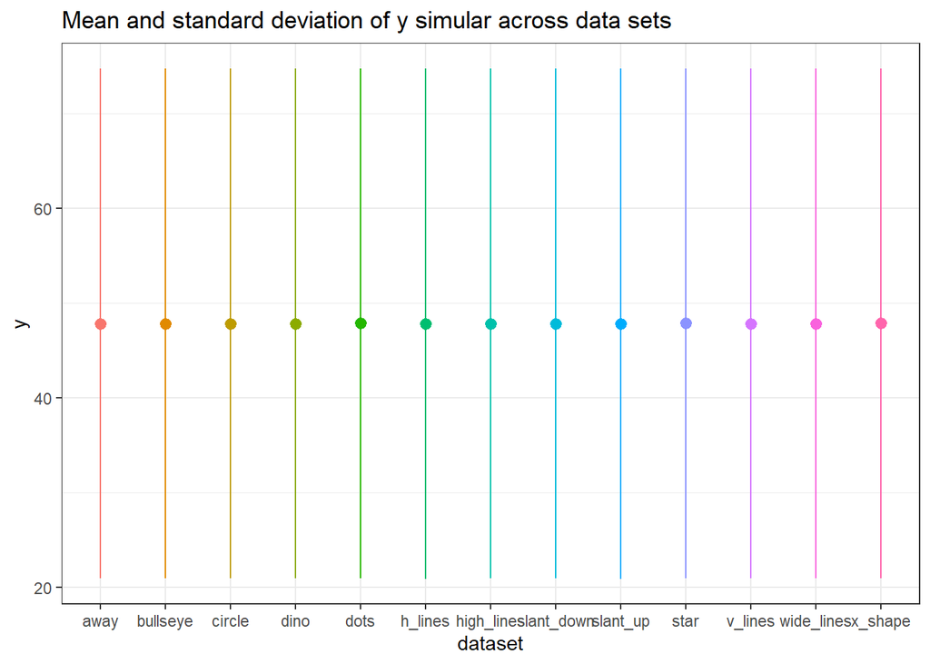

```r
ggplot(datasaurus, aes(dataset, y, colour=dataset))+
  stat_summary(fun.data = "mean_sdl",
               fun.args = list(mult = 1),
               show.legend = F) +
  labs(title = "Mean and standard deviation of y simular across data sets")
```

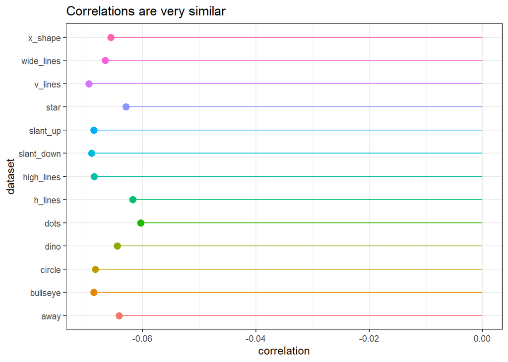

```r
datasaurus %>%
  group_by(dataset) %>%
  summarise(correlation = cor(x,y)) %>%
  ggplot(aes(correlation, dataset, color = dataset)) +
  geom_point(show.legend = F, size = 3) +
  geom_segment(aes(x = 0, xend=correlation, y = dataset, yend = dataset ),
               show.legend = F) +
  scale_x_continuous(limits = c(-.07,0)) +
  labs(title = "Correlations are very similar")
```

## Boxplots

Tukey’s five number summary via the boxplot proves to be robust against this error. The main point of visualizing the actual data stands, but using multiple summary frameworks has a lot of merit as part of a data analysis.

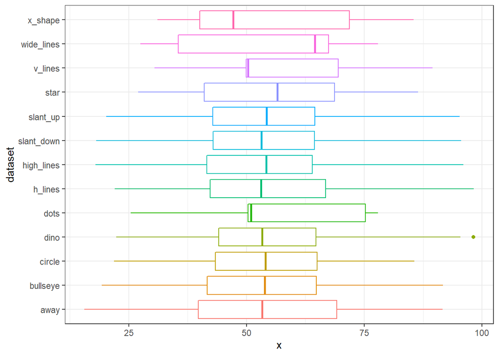

```r
datasaurus %>%
  ggplot(aes(x, dataset, color = dataset)) +
  geom_boxplot(show.legend = F)
```

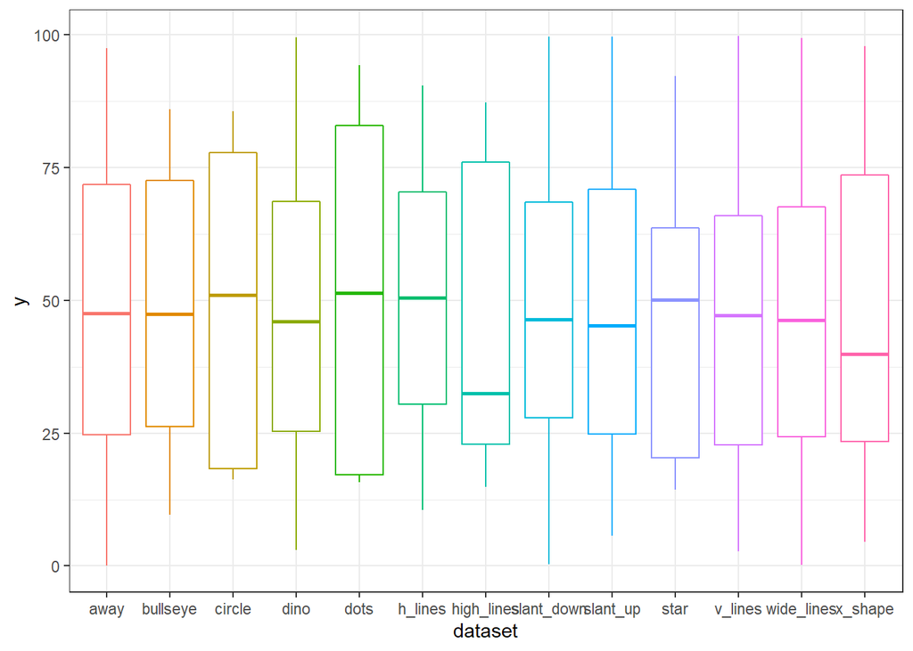

```r
datasaurus %>%
  ggplot(aes(dataset, y, color = dataset)) +
  geom_boxplot(show.legend = F)
```